# Ford GoBike Trends & Statistics

## by Farouk Bello

## Total number of rides made on each day of week

> The visualization showed the bar chart of the total number of rides made on each day of week. To better understand the data a generic color was used for all the bars signifying totals and nothing else.

> The visualizatioon showed that week days are busier than weekends with Thursday having the highest no of rides while Saturday have the lowest.

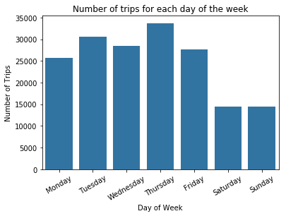

## Which class of people made most of the rides?

> The visualization below showed twoo bar charts displayed side by side which majorly tell us that there are two forces in play when it comes to deducing those that are making most of the rides.

> It can be seen that Subscribers are the ones making most of the rides for every day of week. And it can also be seen that male dominates in the second chart for every day of the week with *Females & Others* taking relatively small portion of the rides. From this it was deduced that **Male Subscribers** are the ones making most of the rides and they do so for every day of the week.

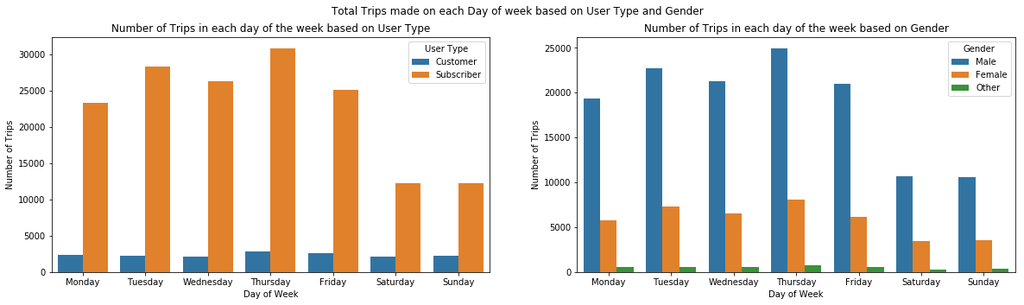

## Are male subscribers riding for a long time?

> There are 3 visualizations in this section. The first one shows the average trip duration for individual ages in the Dataset. It can be seen that people within the age range 20 to 65 generally engage have average short duration rides while people above 65 have uncommon duration (sometimes long and sometimes short)

> The second visualization took the first one a step further by showing two plots based on user type. Hence we see that Subscribers that we have seen to contribute more to the Dataset majorly have short average trip duration while customers have longer average trip durations.

> The third visualization followed a similar approach as visualization two but it classified the average trip durations by gender not user type. It is in this section that we got the last evidence to provide answer to our question. We can see that male and female trip durations are closely packed but a careful examination of the plot showed that females generally ride for a long time than males.

> So these three visualizations provided the evidence that **Male Subscribers don't ride for a long time**. But *Female Customers* ride for a long time as the customers have more average trip durations than subscribers and females have slightly higher average trip durations than males.

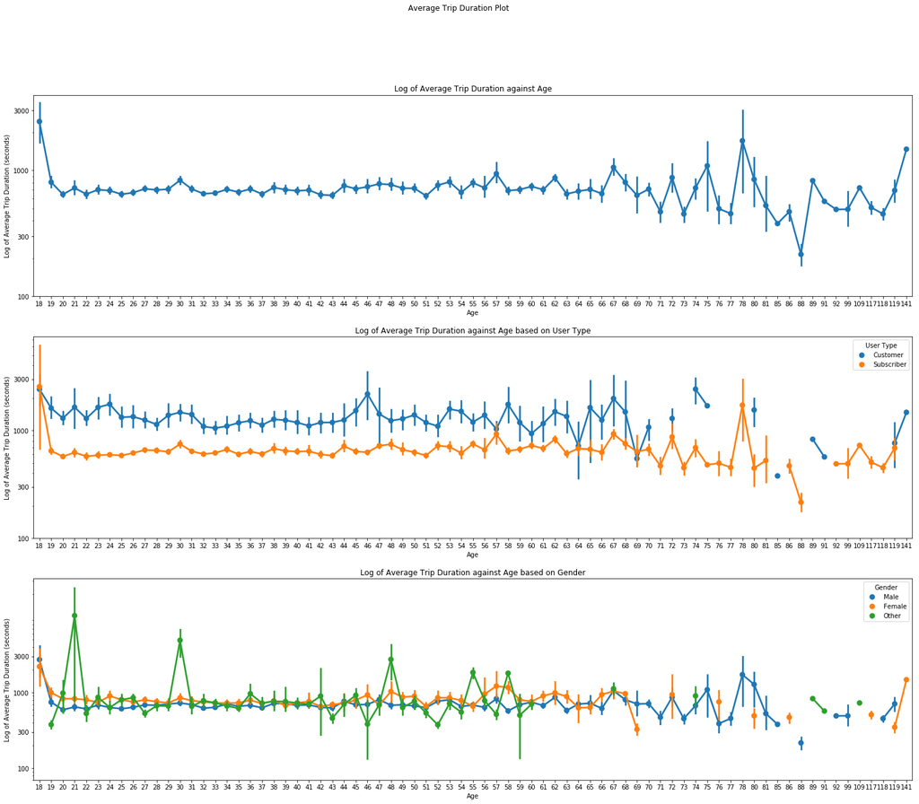